# 随机行走撒点求面积

22920242203150 2025-11-16

课程代码均在如下 GitHub 仓库开源：https://github.com/GHe0000/scientific-programming-intro

## 目录

- 作业要求
- 思路
- 实现
- 均值与标准差与撒点数关系
  - 均值
  - 标准差
- 最大步幅与均值和标准差关系
  - 均值
  - 标准差
  - 最优最大步长与 $N$ 关系
- 撒点的分布
  - 热力图
  - 边缘分布
- 结论
- 参考资料
- 致谢
- 附一：问题
- 附二：学习心得

## 作业要求

通过二维平面上的随机行走撒点，求圆面积。注意，若走出**方框**，退回去撒一个点，若再走出去，再退回，再撒一个点。探索一下内容：

- 均值和标准差与步数（撒点数）的关系。
- 最大步幅如何影响均值和标准差？
- 撒的点在方框内是什么分布？

## 思路

不失一般性，我们设圆的半径为 $r=1$，同时取的求解范围为 $[-1,1]\times[-1,1]$. 对于其他半径，其只是一个常数倍数关系. 在求解面积比时会被约掉. 因此，圆的半径对我们之后的求解过程没有本质的影响.

这里我们通过随机行走来进行采样，因此，我们从 $X=(0,0)$ 开始，并随机取： $$ \Delta X = (\Delta x,\Delta y),\quad ,\Delta x, \Delta y \sim U(-S,S) $$ 其中 $S$ 为最大步长. 同时，如果 $X+\Delta X$ 超过求解区域则拒接点并回退点. 给定求解步数 $N$ 和 $S$，统计在圆内部的点的数量 $N_{in}$， 并得到估计值：

$$ S_{\circ} = \frac{N_{in}}{N} S_{\square} = 4 \frac{N_{in}}{N} $$

## 实现

这里我们先导入需要的库，并针对 Jupyter Notebook 进行一些设置.

```python
import numpy as np # 数值计算库
import numba as nb # 引入 jit 来加速函数（如果需要）
import sympy as sym # 符号计算库
import matplotlib as mpl
import matplotlib.pyplot as plt # 图像绘制
from matplotlib.backends.backend_agg import FigureCanvasAgg # 设置图像后端用
import ipywidgets as ipw # 交互控件
from IPython.display import display, Math, Latex # 打印数学公式
import time

import matplotlib.animation as animation # 创建动画
from IPython.display import HTML # 动画嵌入
import scipy

# 使用 mathjax 来在 jupyter notebook 显示数学公式
sym.init_printing(use_latex='mathjax')

# 设置 matplotlib 绘制的图像嵌入到 jupyter notebook 的方式
%matplotlib widget

# 一个工具函数，可以让静态图片不经过 widget 直接嵌入 Jupyter notebook
# 这样图片可以直接存到 nb 文件里，而不是需要运行才能显示（类似 inline）
def display_inline(fig):
    fig.set_canvas(FigureCanvasAgg(fig))
    display(fig)
    plt.close(fig) # 释放 fig，减小资源消耗

# 一个工具函数，用于在 Jupyter 中快速实现公式和字符串混合输出
def display_math(*args):
    parts = []
    for a in args:
        if isinstance(a, str):
            parts.append(a)
        else:
            parts.append(sym.latex(a))
    display(Math("".join(parts)))

# 设置 matplotlib 使用的字体，避免出现中文问题
plt.rcParams['font.family'] = ['SimSun', 'Times New Roman']
plt.rcParams['mathtext.fontset'] = 'cm'
# 设置默认坐标轴字体大小
plt.rcParams['axes.labelsize'] = 14
```

为了保证结果的可复现性，我们在开头设置一下随机数种子，并在之后不再改变. 这样对于每次从头运行，其得到的结果都是相同的. 但对于不同单元格，同个单元格多次运行，其结果仍旧是随机的.

```python
np.random.seed(3407)
```

这里我们给出两个函数，其中第一个会返回取的点（方便可视化），第二个直接统计 $N_{in}$，并返回结果. 每个函数均需要 $N$ 和 $S$ 两个参数. 同时两个函数均使用 `Numba` 进行优化.

```python
@nb.njit(cache=True)
def gen_walk(N,S):
    pts = np.zeros((N,2))
    X = np.zeros(2)
    Nin = 1 # 初始点在内
    for i in range(1,N):
        dX = np.random.uniform(-S,S,2)
        if np.all(np.abs(X+dX)<=1.0):
            X += dX
        pts[i] = X
        if X[0]**2+X[1]**2<=1.0:
            Nin += 1
    return pts, 4*Nin/N

@nb.njit(cache=True)
def calc(N, S):
    X = np.zeros(2)
    Nin = 1
    for i in range(1, N):
        dX = np.random.uniform(-S,S,2)
        if np.all(np.abs(X+dX)<=1.0):
            X += dX
        if X[0]**2+X[1]**2<=1.0:
            Nin += 1
    return 4*Nin/N
```

下面我们给定 $N=1000$, $S=0.3$，计算并绘制图像.

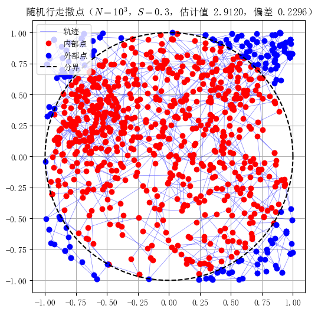

```python
N = 1000
S = 0.3
pts, S_calc = gen_walk(N,S)
inside_idx = np.linalg.norm(pts,axis=1) <= 1.0
fig, ax = plt.subplots(figsize=(8,6))
ax.set_aspect("equal")
ax.plot(pts[:,0],pts[:,1], "b-", lw=0.5, alpha=0.5, label="轨迹")
ax.plot(pts[inside_idx][:,0],pts[inside_idx][:,1], "ro", label="内部点")
ax.plot(pts[~inside_idx][:,0],pts[~inside_idx][:,1], "bo", label="外部点")
phi_bnd = np.linspace(0, 2 * np.pi, 400)
ax.plot(np.cos(phi_bnd), np.sin(phi_bnd), "k--", label="分界")
ax.grid()
ax.legend(loc="upper left")
ax.set_title(f"随机行走撒点（$N=10^{np.log10(N):.0f}$，$S=${S}，估计值 {S_calc:.4f}，偏差 {np.pi-S_calc:.4f}）")
display_inline(fig)
```

我们增大 $N$，观察计算结果变化：

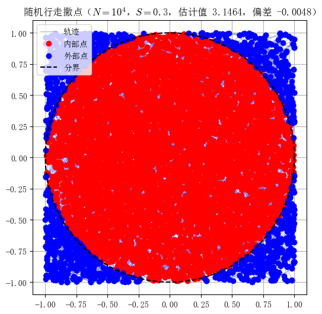

```python
N = 10000
S = 0.3
pts, S_calc = gen_walk(N,S)
inside_idx = np.linalg.norm(pts,axis=1) <= 1.0
fig, ax = plt.subplots(figsize=(8,6))
ax.set_aspect("equal")
ax.plot(pts[:,0],pts[:,1], "b-", lw=0.5, alpha=0.5, label="轨迹")
ax.plot(pts[inside_idx][:,0],pts[inside_idx][:,1], "ro", label="内部点")
ax.plot(pts[~inside_idx][:,0],pts[~inside_idx][:,1], "bo", label="外部点")
phi_bnd = np.linspace(0, 2 * np.pi, 400)
ax.plot(np.cos(phi_bnd), np.sin(phi_bnd), "k--", label="分界")
ax.grid()
ax.legend(loc="upper left")
ax.set_title(f"随机行走撒点（$N=10^{np.log10(N):.0f}$，$S=${S}，估计值 {S_calc:.4f}，偏差 {np.pi-S_calc:.4f}）")
display_inline(fig)
```

可以看到，随着 $N$ 增加，计算的误差变小了，这是符合我们的预期的. 下面我们研究估计的均值和标准差与撒点数的关系.

## 均值与标准差与撒点数关系

### 均值

我们统计 $N = 10^3,10^4,10^5,10^6,10^7$ 时的均值和标准差. 对于每一个 $N$，我们计算 $M=100$ 次并进行统计：

> 为了加速，这里使用 `Numba` 编译优化并并行计算

```python
@nb.njit(cache=True, parallel=True)
def calcM(N_arr, S, M):
    n_N = len(N_arr)
    ret = np.zeros((n_N, M))
    for i in range(n_N):
        N = N_arr[i]
        for j in nb.prange(M):
            ret[i,j] = calc(N,S)
    return ret
```

```python
N_arr = np.array([10**3,10**4,10**5,10**6,10**7])
st = time.time()
S_arr = calcM(N_arr, 0.3, 100)
print(f"计算耗时：{time.time()-st:2f}s")
```

```
计算耗时：95.041865s
```

我们绘制 $N$ 与均值的关系如图：

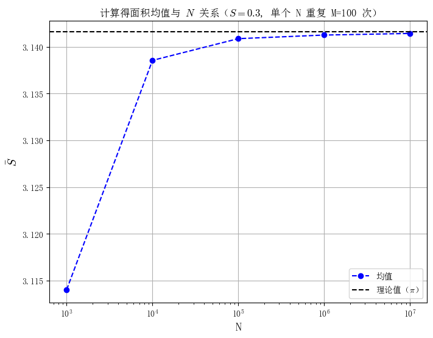

```python
mean_arr = np.mean(S_arr,axis=1)
fig, ax = plt.subplots(figsize=(8,6))
ax.plot(N_arr, mean_arr, "b--o", label="均值")
ax.set_xscale("log")
ax.set_xlabel("N")
ax.set_ylabel("$\\bar{S}$")
ax.set_title("计算得面积均值与 $N$ 关系（$S=0.3$, 单个 N 重复 M=100 次）")
ax.axhline(np.pi,c="k",ls="--", label="理论值（$\\pi$）")
ax.grid()
ax.legend()
display_inline(fig)
```

可以看见，随着 $N$ 增大，$\bar{S}$ 变化不大（只是在小数点后第二位变化，大体上是没有变化的）且越来越接近理论值.

### 标准差

同样，我们可以绘制标准差与 $N$ 的关系：

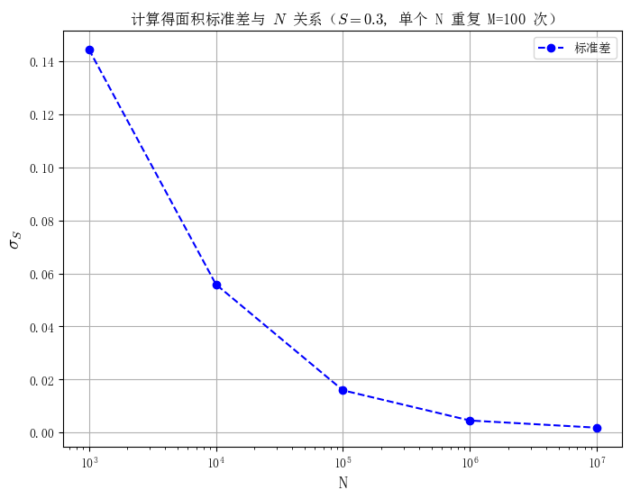

```python
std_arr = np.std(S_arr,axis=1)
fig, ax = plt.subplots(figsize=(8,6))
ax.plot(N_arr, std_arr, "b--o", label="标准差")
ax.set_xscale("log")
ax.set_xlabel("N")
ax.set_ylabel("$\\sigma_{S}$")
ax.set_title("计算得面积标准差与 $N$ 关系（$S=0.3$, 单个 N 重复 M=100 次）")
ax.grid()
ax.legend()
display_inline(fig)
```

可以看见，其标准差随着 $N$ 增大而变小，同时看上去符合某种幂律分布的形式. 根据课堂上的推导应该是 $\sigma_S \propto 1/\sqrt{N}$. 这里使用 log-log 坐标观察：

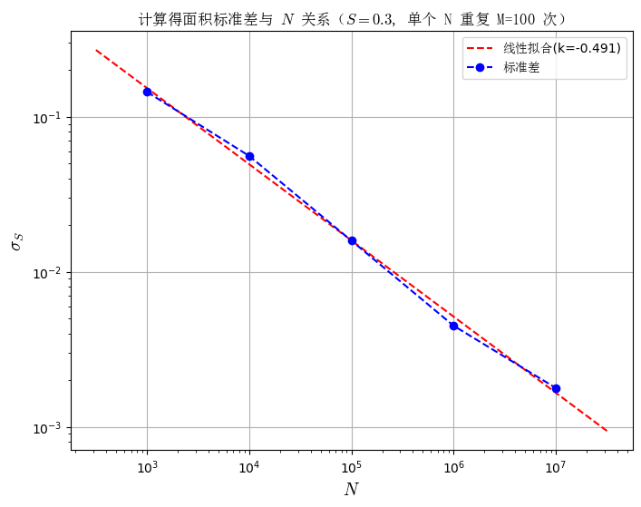

```python
std_arr = np.std(S_arr,axis=1)

k_fit ,b_fit = np.polyfit(np.log(N_arr), np.log(std_arr), deg=1)
N_fit = np.logspace(2.5, 7.5, num=200)
fit_line = np.exp(b_fit) * (N_fit ** k_fit)

plt.rcParams['font.family'] = ['DejaVu Sans','SimSun', 'Times New Roman'] # 临时设置字体，消除上标的负号问题
fig, ax = plt.subplots(figsize=(8,6))
ax.plot(N_fit, fit_line, "r--", label=f"线性拟合(k={k_fit:.3f})")
ax.plot(N_arr, std_arr, "b--o", label="标准差")
ax.set_xscale("log")
ax.set_yscale("log")
ax.set_xlabel("$N$")
ax.set_ylabel("$\\sigma_{S}$")
ax.set_title("计算得面积标准差与 $N$ 关系（$S=0.3$, 单个 N 重复 M=100 次）", fontfamily="SimSun")
ax.grid()
ax.legend()
display_inline(fig)
plt.rcParams['font.family'] = ['SimSun', 'Times New Roman']
```

可以看到其在 log-log 坐标下确实是一条直线，且拟合斜率为 $-0.491 \approx -0.5$，和课堂上的推导是相吻合的（中心极限定理）.

## 最大步幅与均值和标准差关系

### 均值

我们固定 $N=10^4$，统计 $S=0.1,0.2,\dots,4.0$ 时的均值与标准差. 对于每一个 $S$，我们重复 $M=1000$ 次.

```python
@nb.njit(cache=True, parallel=True)
def calcS(N, S_arr, M):
    n_S = len(S_arr)
    ret = np.zeros((n_S, M))
    for i in range(n_S):
        S = S_arr[i]
        for j in nb.prange(M):
            ret[i,j] = calc(N,S)
    return ret
```

```python
Sm_arr = np.arange(0.1,4.1,0.1)
st = time.time()
S_arr = calcS(10000, Sm_arr, 1000)
print(f"计算耗时：{time.time()-st:2f}s")
```

```
计算耗时：28.303016s
```

我们绘制最大步长 $S$ 与均值的关系：

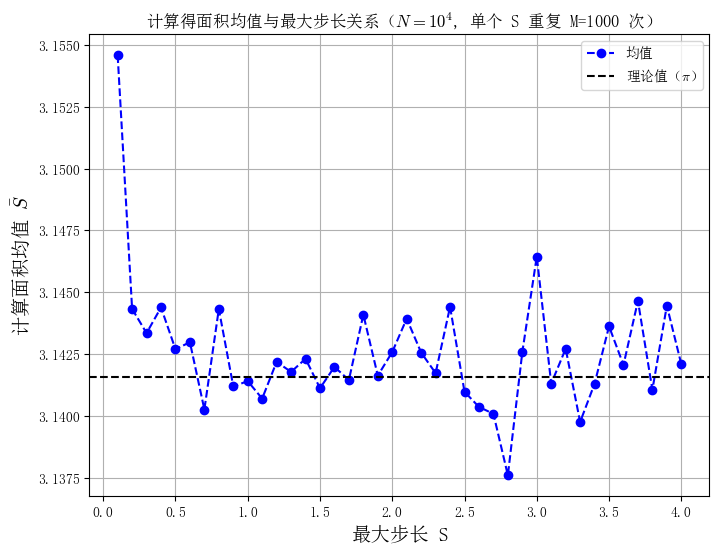

```python
mean_arr = np.mean(S_arr,axis=1)
fig, ax = plt.subplots(figsize=(8,6))
ax.plot(Sm_arr, mean_arr, "b--o", label="均值")
ax.set_xlabel("最大步长 S")
ax.set_ylabel("计算面积均值 $\\bar{S}$")
ax.set_title("计算得面积均值与最大步长关系（$N=10^4$, 单个 S 重复 M=1000 次）")
ax.axhline(np.pi,c="k",ls="--", label="理论值（$\\pi$）")
ax.grid()
ax.legend()
display_inline(fig)
```

可以看见，随着 $S$ 增大，$\bar{S}$ 变化不大（只是在小数点后第二位变化，大体上是没有变化的）.

### 标准差

我们绘制最大步长与标准差的关系：

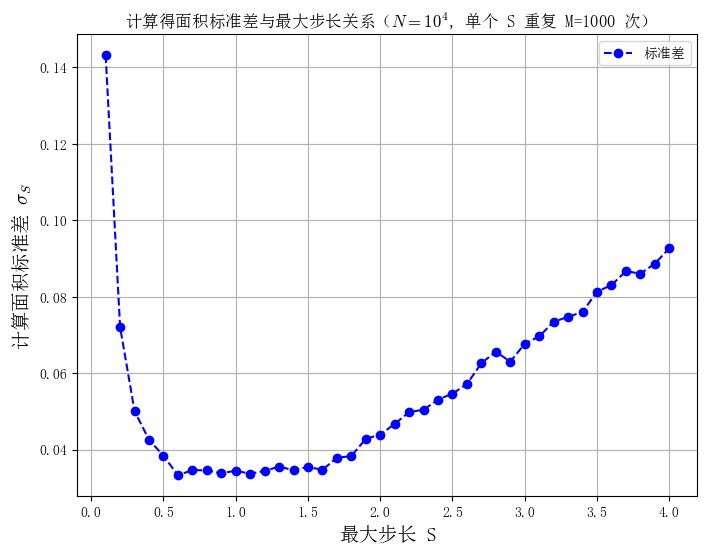

```python
std_arr = np.std(S_arr,axis=1)
fig, ax = plt.subplots(figsize=(8,6))
ax.plot(Sm_arr, std_arr, "b--o", label="标准差")
ax.set_xlabel("最大步长 S")
ax.set_ylabel("计算面积标准差 $\\sigma_{S}$")
ax.set_title("计算得面积标准差与最大步长关系（$N=10^4$, 单个 S 重复 M=1000 次）")
ax.grid()
ax.legend()
display_inline(fig)
```

可见，随之最大步长 $S$ 的增大，标准差 $\sigma_S$ 先减小后增大. 其中最小的位置大致出现在最大步长为 $0.6-1.0$ 附近.

上述先变小后增大的现象是可以理解的. 当最大步长 $S$ 较小时，随机行走的范围比较小. 因此难以遍历空间各处. 但最大步长 $S$ 较大时，随机行走就很容易超出边界外. 从而导致分布不均匀.

### 最优最大步长与 $N$ 关系

这里我们想知道最优最大步长是否与 $N$ 有关？还是是一个固定的值.

这里我们令 $N=10^3,5\times 10^3,10^4,5 \times 10^4,10^5$，并使用 0.618 法搜索给定 $N$ 的最优的最大步长 $S$.

为了减小随机带来的影响，我们取 $M=10^4$.

```python
@nb.njit()
def searchS(N, M, max_iter=100, tol=0.01):
    def calc_std(N,S,M):
        res = np.zeros(M)
        for i in range(M):
            res[i] = calc(N,S)
        return np.std(res)
    inv_phi = (np.sqrt(5)-1)/2
    inv_phi_sq = (3-np.sqrt(5))/2

    a, b = 0.1, 4.0
    h = b - a
    c = a + inv_phi_sq * h
    d = a + inv_phi * h

    fc = calc_std(N, c, M)
    fd = calc_std(N, d, M)

    for _ in range(max_iter):
        h = b - a
        if h <= tol:
            break
        if fc < fd:
            b = d
            d = c
            fd = fc
            c = a + inv_phi_sq * (b - a)
            fc = calc_std(N, c, M)
        else:
            a = c
            c = d
            fc = fd
            d = a + inv_phi * (b - a)
            fd = calc_std(N, d, M)
    if fc < fd:
        return c
    else:
        return d
```

```python
@nb.njit(cache=True, parallel=True)
def searchSN(N_arr, M, max_iter=100, tol=0.01):
    n_N = len(N_arr)
    ret = np.zeros(n_N)
    for i in nb.prange(n_N):
        N = N_arr[i]
        ret[i] = searchS(N, M, max_iter, tol)
    return ret
```

```python
N_arr = np.array([10**3, 5*10**3, 10**4, 5*10**4, 10**5])
#N_arr = np.array([10**3, 5*10**3, 10**4])
st = time.time()
Sm_arr = searchSN(N_arr, 10000)
print(f"计算耗时：{time.time()-st:2f}s")
```

```
计算耗时：3082.867642s
```

我们绘制出找到的最优最大步长和 $N$ 的关系如下图：

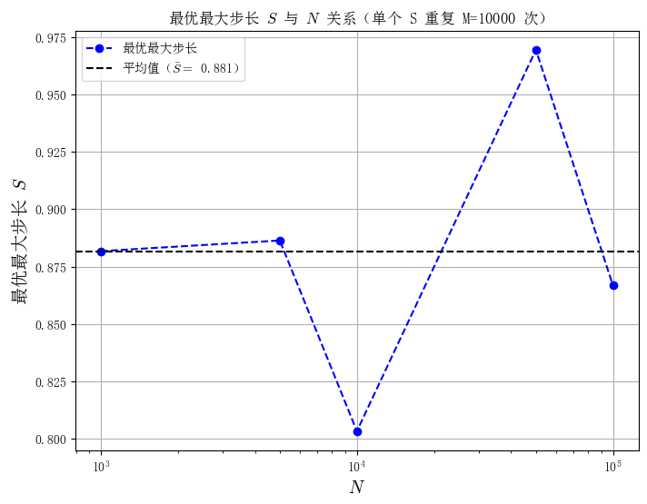

```python
fig, ax = plt.subplots(figsize=(8, 6))
ax.plot(N_arr, Sm_arr, "b--o", label="最优最大步长")
ax.set_xscale("log")
ax.set_xlabel("$N$")
ax.set_ylabel("最优最大步长 $S$")
ax.set_title("最优最大步长 $S$ 与 $N$ 关系（单个 S 重复 M=10000 次）")
ax.axhline(np.mean(Sm_arr),c="k",ls="--", label=f"平均值（$\\bar{{S}}=$ {np.mean(Sm_arr):.3f}）")
ax.grid()
ax.legend()
display_inline(fig)
```

可以看见，最优最大步长和 $N$ 关系不大，基本是一个定值. 为 $0.88$ 左右.

## 撒点的分布

### 热力图

下面我们来研究撒点的分布，我们令 $N=10^5$，$S=0.88$ （前文得到的最优步长）, 并绘制热力图（给区域分网格，每一格的颜色与这一格内的点数有关，类似于一个二维的直方图，只是用颜色表示频率）.

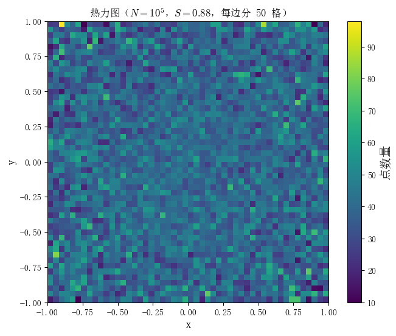

```python
N = 100000
S = 0.88

pts, S_calc = gen_walk(N,S)

fig, ax = plt.subplots(figsize=(8, 6))
hist, xedges, yedges, im = ax.hist2d(
        pts[:,0], pts[:,1],
        bins=50,
        cmap='viridis',
        #norm=mpl.colors.LogNorm(),
        range=[[-1, 1], [-1, 1]]
    )
bnd_theta = np.linspace(0, 2 * np.pi, 400)
#ax.plot(np.cos(bnd_theta), np.sin(bnd_theta), "k--", label="边界")
fig.colorbar(im, ax=ax, label="点数量")
ax.set_title(f"热力图（$N=10^{np.log10(N):.0f}$，$S={S}$，每边分 50 格）")
ax.set_xlabel("x")
ax.set_ylabel("y")
ax.set_aspect('equal')
display_inline(fig)
```

可以看见，每一格的颜色基本相同，也就是每一格的点的数量基本相同，因此我们可以猜测其是均匀分布（这个猜测是合理的，因为只有在求解区域内是均匀分布我们才能通过概率得到面积比）.

下面我们用其他方法进一步验证其确实是均匀分布.

### 边缘分布

如果原先的点确实是均匀的，那么其边缘分布（点的 $x$ 坐标分布和 $y$ 坐标分布）应该是均匀的. 因此，我们绘制出点的 $x$ 坐标的分布和 $y$ 坐标的分布. 并和理论对比.

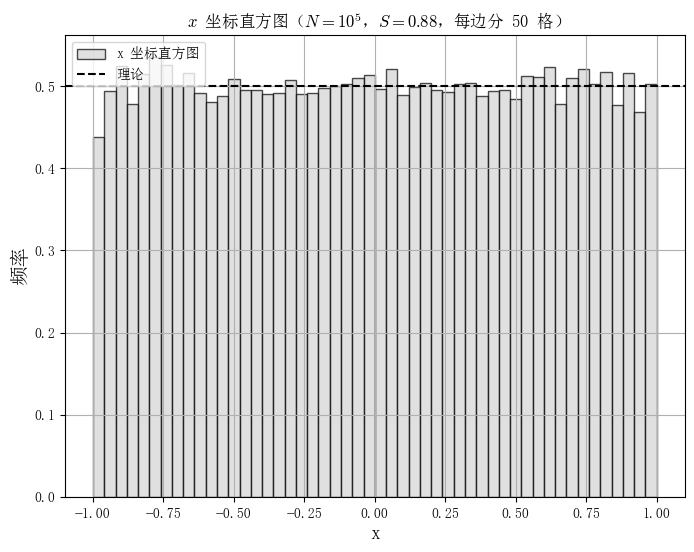

```python
fig, ax = plt.subplots(figsize=(8, 6))
count, bins, _ = ax.hist(pts[:,0], bins=50, density=True, color='lightgray', edgecolor='k', alpha=0.7, label="x 坐标直方图")
ax.axhline(0.5, ls="--", c="k", label="理论")
ax.set_xlabel("x")
ax.set_ylabel("频率")
ax.grid()
ax.legend(loc="upper left")
ax.set_title(f"$x$ 坐标直方图（$N=10^{np.log10(N):.0f}$，$S={S}$，每边分 50 格）")
display_inline(fig)
```

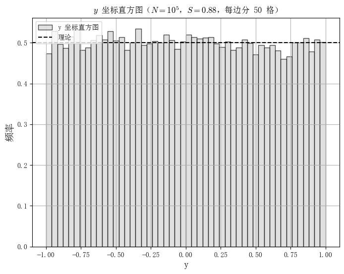

```python
fig, ax = plt.subplots(figsize=(8, 6))
count, bins, _ = ax.hist(pts[:,1], bins=50, density=True, color='lightgray', edgecolor='k', alpha=0.7, label="y 坐标直方图")
ax.axhline(0.5, ls="--", c="k", label="理论")
ax.set_xlabel("y")
ax.set_ylabel("频率")
ax.grid()
ax.legend(loc="upper left")
ax.set_title(f"$y$ 坐标直方图（$N=10^{np.log10(N):.0f}$，$S={S}$，每边分 50 格）")
display_inline(fig)
```

可以看到，两个边缘分布均是均匀分布，且分布和我们的理论是吻合的. 这进一步说明了撒点的分布确实是均匀分布.

## 结论

综上，我们实现了通过随机行走撒点求面积. 并探究了以下问题：

- 随着撒点数 $N$ 增大，均值基本保持不变，但标准差减小，且符合 $\sigma_S \propto N^{-1/2}$
- 随着最大步长的增大，均值基本保持不变，但标准差先减小再增大.
- 最优最大步长（标准差最小的最大步长）与 $N$ 基本无关，对于此问题基本是一个固定值，为 $0.88$
- 随机行走的撒点分布是一个均匀分布，这里通过热力图和边缘分布进行验证.

最大步长的增大标准差先减小再增大是可以理解的，当最大步长较小时，随机行走的范围比较小. 因此难以遍历空间各处. 但最大步长 $S$ 较大时，随机行走就很容易超出边界外. 从而导致分布不均匀.

## 参考资料

- 盛骤等, 概率论与数理统计, 第五版. §3 多维随机变量及其分布
- 部分代码编写时使用 Fitten Code AI 进行补全
- 代码实现中使用 Google Gemini AI 查询了一些函数的用法.

## 致谢

暂无

## 附一：问题

- 为什么这种方式的随机行走的撒点分布是一个均匀分布，不是其他分布？如何严格证明其确实是均匀分布？
- 最优最大步长是否能严格求解？还是只有某个经验取法？

## 附二：学习心得

- 随机行走生成均匀分布